# Predicting Wildfire Size

Iris Foxfoot, Seonga Cho, Vanessa Echeverri Figueroa

15/3/2022

```r
knitr::opts_chunk$set(
    echo = TRUE,
    message = FALSE,
    warning = FALSE
)

library(tidyverse) #used for data wrangling and viz
library(here) #simplifies file paths
library(rsample) #used to split data
library(janitor) #used to clean data names
library(corrplot) #for correlation viz
library(VIM) #for missing data viz
library(missMDA) #for imputing missing data
library(ggfortify) #for PCA viz
library(fastDummies) #for dummy coding
library(caret) #for cross validation
library(class) #for knn
library(gbm) #for boosted trees modeling
library(randomForest) #for random forest modeling
library(maptools)
library(RColorBrewer)
library(classInt)
library(ggplot2)
library(ggrepel)
library(mapproj)
library(viridis)
library(pander)
#turns scientific notation off
options(scipen = 100)

#some of our workflow includes randomness. here we set a seed so our workflow can be reproduced without worrying about random variation
set.seed(123)
```

# 1 Introduction

The purpose of this project is to use machine learning techniques to predict the size of a fire in case a wildfire occurs at a certain location, considering different characteristics for climate, vegetation location, season, among others. Our most accurate model will then be used to assess how different physical and climate characteristics may influence wildfires predicted size and potentially support decisions to prevent damages to structures and injuries to vulnerable populations.

## 1.1 Background

Wildfires have been intensifying in United States during the last decades, not only in ocurrence, but in flame size. Their causes range between propensity due to physical characteristics (see Keeley et al., 2009) to external factors, such as fires caused by Native American population practices (Stephens et al., 2007), climate change, among other reasons. They have not only caused several injuries to the population, even deaths, but have also destroyed structures and caused damage that are costly to repair (Keeley et al., 2009). Despite wildfires are necessary to provide nutrients to the forest and maintain it healthy as part of its regular lifecycle, understading their intensification and causes may provide an outlook to prevent wildfires from escalating to disproporcionate sizes.

## 1.2 Why this model is useful

Since this model will help to understand why fires can grow to a catastrophical size, it will be used to predict the fire size in presence of wildfire. This information can be valuable to support policy makers in prevention of deaths, affection to structures, protection to vulnerable populations, and creation of emergency plans.

## 1.3 Data and Packages Used

This dataset is available on [Kaggle](https://www.kaggle.com/capcloudcoder/us-wildfire-data-plus-other-attributes/code) and it is a subset of larger fires.

Important attributes include

- `fire_size` - the size of the fire in acres
- `stat_cause_descr` - the cause of the fire
- `vegetation` - code corresponding to vegetation type
- `temp_cont` - temperature (Celsius) when the fire was contained

A complete codebook is available in the project file

```r
#read in dataset
us_wildfire <- read_csv(here("archive", "FW_Veg_Rem_Combined.csv"))
#Following to the National Geographic Education
us_wildfire$region = "NorthEast"
us_wildfire[which(us_wildfire$state %in% c("AK", "WA", "OR", "CA", "NV", "ID", "MT", "WY", "UT", "CO")),"region"] = "West"
us_wildfire[which(us_wildfire$state %in% c("AZ", "NM", "TX", "OK")), "region"] = "SouthWest"
us_wildfire[which(us_wildfire$state %in% c("ND", "SD", "NE", "KS", "MN", "IA", "MO", "WI", "IL", "MI", "IN", "OH")), "region"] = "MidWest"
us_wildfire[which(us_wildfire$state %in% c("AR", "LA", "MS", "AL", "GA", "FL", "SC", "NC", "TN", "KY", "VA", "WV")), "region"] = "SouthEast"

us_wildfire$year_diff = us_wildfire$disc_pre_year - min(us_wildfire$disc_pre_year)
```

# 2 Methods

## 2.1 Cleaning Data

```r
#First, there are a couple of junk columns in the data, so we select only the columns that mean something, then we use janitor's clean names function for lowercase snake col names
us_wildfire_clean <- us_wildfire %>%
  dplyr::select(fire_name:year_diff) %>%
  clean_names()

#we are interested in using weather to predict fire duration, so we filter out observations that do not have a weather file
us_wildfire_clean <- us_wildfire_clean %>%
  filter(weather_file != "File Not Found")

#Here we label vegetation according to the provided codebook
us_wildfire_clean <- us_wildfire_clean %>%
  mutate(vegetation_classed = case_when(
    vegetation == 12 ~ "Open Shrubland",
    vegetation == 15 ~ "Polar Desert/Rock/Ice",
    vegetation == 16 ~ "Secondary Tropical Evergreen Broadleaf Forest",
    vegetation == 4 ~ "Temperate Evergreen Needleleaf Forest TmpENF",
    vegetation == 9 ~ "C3 Grassland/Steppe",
    vegetation == 14 ~ "Desert"
  ))

#According the metadata for this data set, the vegetation was created by interpolating most likely vegetation based on latitude and longitude. The most common vegetation type is listed as "Polar Desert/Rock/Ice" and this seems very unlikely.

#There are some weather observations for which every weather field is 0. this seems unlikely. so we will replace them with NA
us_wildfire_clean <- us_wildfire_clean %>%
  mutate_at(vars(temp_pre_30:hum_cont), ~na_if(., 0.0000000))
#precipitation is frequently zero, so we will not replace all zeros with NAs. Instead we will follow the pattern of NAs seen in other weather columns.

#we can see that there is a clear pattern in the missing weather data. when temp_pre_30 is missing, so is wind_pre_30 and humidity_pre_30. We will assume this extends to precipitation
us_wildfire_clean <- us_wildfire_clean %>%
  mutate(prec_pre_30 = case_when(is.na(temp_pre_30) & is.na(hum_pre_30) & is.na(wind_pre_30) ~ NA_real_,
                                      TRUE ~ prec_pre_30)) %>%
  mutate(prec_pre_15 = case_when(is.na(temp_pre_15) & is.na(hum_pre_15) & is.na(wind_pre_15) ~ NA_real_,
                                      TRUE ~ prec_pre_15)) %>%
  mutate(prec_pre_7 = case_when(is.na(temp_pre_7) & is.na(hum_pre_7) & is.na(wind_pre_7) ~ NA_real_,
                                      TRUE ~ prec_pre_7)) %>%
  mutate(prec_cont = case_when(is.na(temp_cont) & is.na(hum_cont) & is.na(wind_cont) ~ NA_real_,
                                      TRUE ~ prec_cont))

#there are multiple date columns. however, since full dates are mostly missing, we will only keep month and year as variables
us_wildfire_clean <- us_wildfire_clean %>%
  dplyr::select(-disc_clean_date,
         -disc_date_pre,
         -cont_clean_date,
         -disc_pre_month,
         -disc_date_final,
         -cont_date_final,
         -putout_time)

#we also can reclass months into seasons, to reduce factor levels
us_wildfire_clean <- us_wildfire_clean %>%
  mutate(season = case_when(discovery_month %in% c("Apr", "May", "Jun") ~ "Spring",
                            discovery_month %in% c("Jul", "Aug", "Sep") ~ "Summer",
                            discovery_month %in% c("Oct", "Nov", "Dec") ~ "Fall",
                            discovery_month %in% c("Jan", "Feb", "Mar") ~ "Winter")) %>%
  select(-discovery_month)
```

## 2.2 Exploratory Analysis

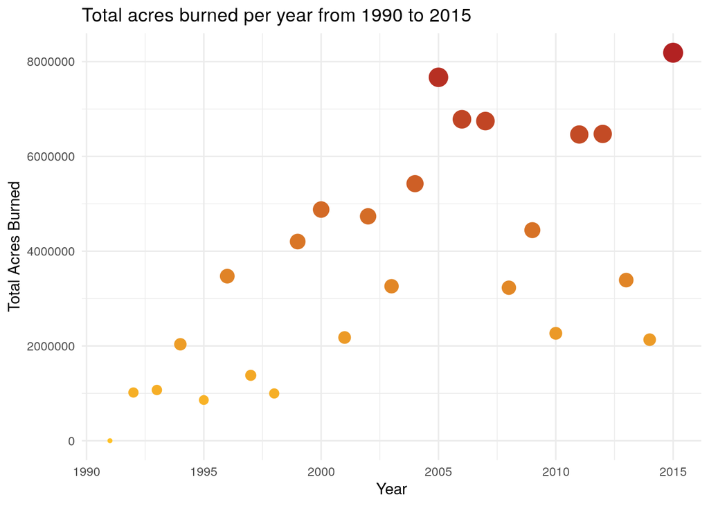

```r
#summarise acres per year burned
acres_per_year <- us_wildfire_clean %>%
  group_by(disc_pre_year) %>%
  summarise(acres_burned = sum(fire_size))

#fire size (finalized graph)
ggplot(data = acres_per_year) +
  geom_point(aes(x = disc_pre_year,
                 y = acres_burned,
                 size = acres_burned,
                 color = acres_burned)) +
  scale_color_continuous(high = "firebrick", low = "goldenrod1") +
  labs(x = "Year", y = "Total Acres Burned",
       title = "Total acres burned per year from 1990 to 2015") +
  theme_minimal() +
  theme(legend.position = "none")
```

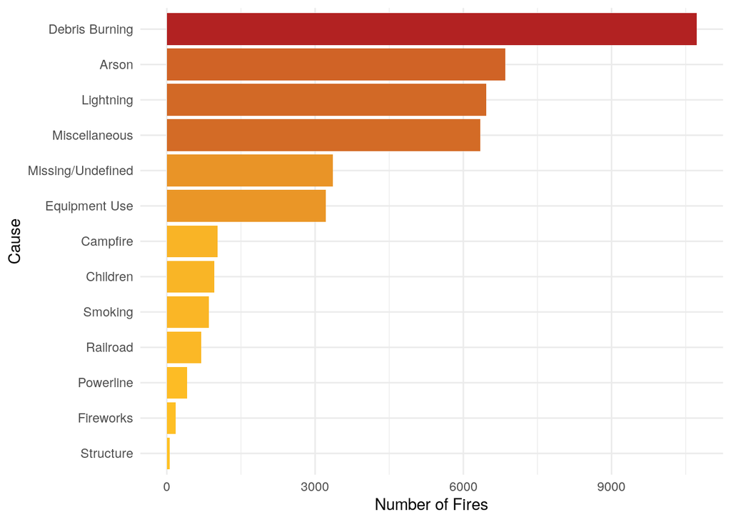

```r
#most common causes of fire
fire_causes <- us_wildfire_clean %>%
  group_by(stat_cause_descr) %>%
  count()

#cause (finalized)
ggplot(data = fire_causes, aes(y = reorder(stat_cause_descr, n), x = n)) +
  geom_col(aes(fill = n)) +
  scale_fill_gradient(high = "firebrick", low = "goldenrod1") +
  labs(x = "Number of Fires",
       y = "Cause",
       tite = "Number of fires per listed starting cause") +
  theme_minimal() +
  theme(legend.position = "none")
```

### 2.2.1 Map of regions

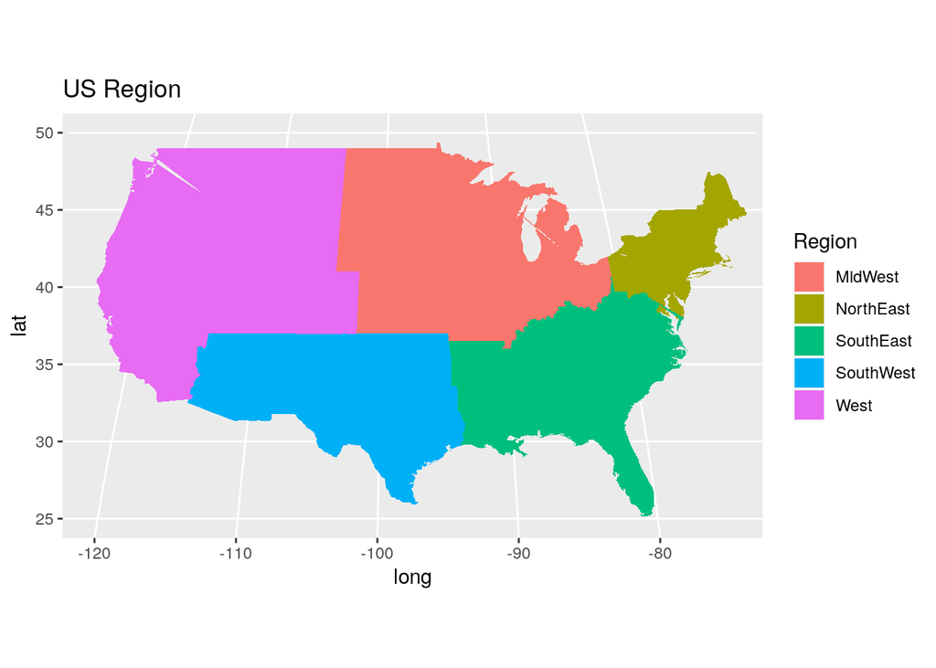

```r
us_wildfire_clean$class_fac = factor(us_wildfire_clean$fire_size_class, levels = c("A", "B", "C", "D", "E", "F", "G"))

us <- map_data("world", 'usa')

state <- map_data("state")

state$region2 = "NorthEast"
state[which(state$region %in% c("alaska", "washington", "oregon", "california", "nevada", "idaho", "montana", "utah", "wyoming", "colorado")), "region2"] = "West"
state[which(state$region %in% c("arizona", "new mexico", "oklahoma", "texas")), "region2"] = "SouthWest"
state[which(state$region %in% c("north dakota", "south dakota", "nebraska", "kansas", "minnesota", "iowa", "missouri", "wisconsin", "illinois", "indiana", "michigan", "ohio")), "region2"] = "MidWest"
state[which(state$region %in% c("arkansas", "louisiana", "mississippi", "alabama", "florida", "georgia", "south carolina", "north carolina", "tennessee", "kentucky", "virginia", "west virginia")), "region2"] = "SouthEast"

#state$region = as.factor(state$region)

ggplot(data=state, aes(x=long, y=lat, group = region)) +
  geom_polygon(aes(fill=region2)) +
  ggtitle("US Region")+
  guides(fill=guide_legend(title="Region"))+
  coord_map(projection = "sinusoidal", xlim=c(-120, -75), ylim = c(25, 50))
```

### 2.2.2 Map of fires

#### 2.2.2.1 The spatial distribution of wildifres

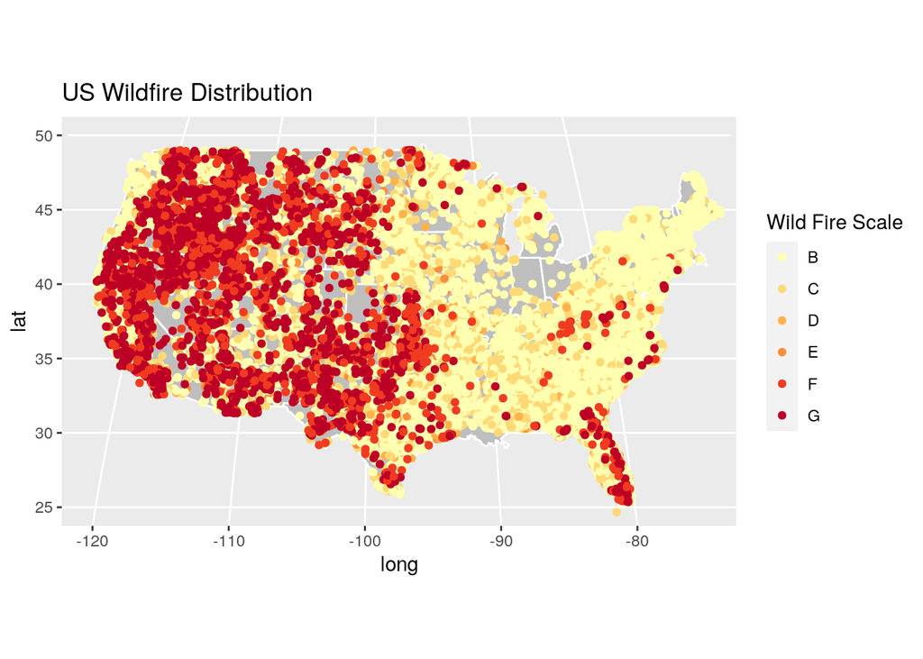

```r
ggplot() +
  geom_polygon(data=state, aes(x=long, y=lat, group=group), color = "white", fill = "grey") +
  geom_point(data = us_wildfire_clean, aes(x=longitude, y = latitude, color = class_fac)) +
  scale_color_brewer(palette = "YlOrRd")+
  ggtitle("US Wildfire Distribution")+
  guides(color=guide_legend(title="Wild Fire Scale"))+
  coord_map(projection = "sinusoidal", xlim=c(-120, -75), ylim = c(25, 50))
```

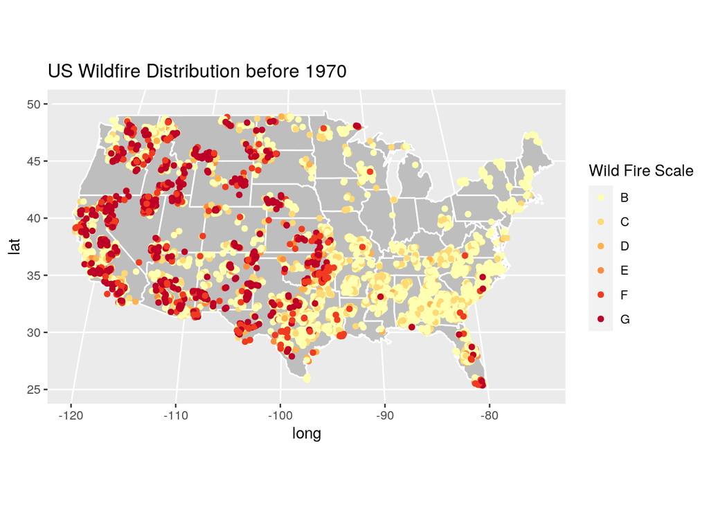

```r
ggplot() +
  geom_polygon(data=state, aes(x=long, y=lat, group=group), color = "white", fill = "grey") +
  geom_point(data = us_wildfire_clean[which(us_wildfire_clean$wstation_byear < 1970),], aes(x=longitude, y = latitude, color = class_fac)) +
  scale_color_brewer(palette = "YlOrRd")+
  ggtitle("US Wildfire Distribution before 1970")+
  guides(color=guide_legend(title="Wild Fire Scale"))+
  coord_map(projection = "sinusoidal", xlim=c(-120, -75), ylim = c(25, 50))
```

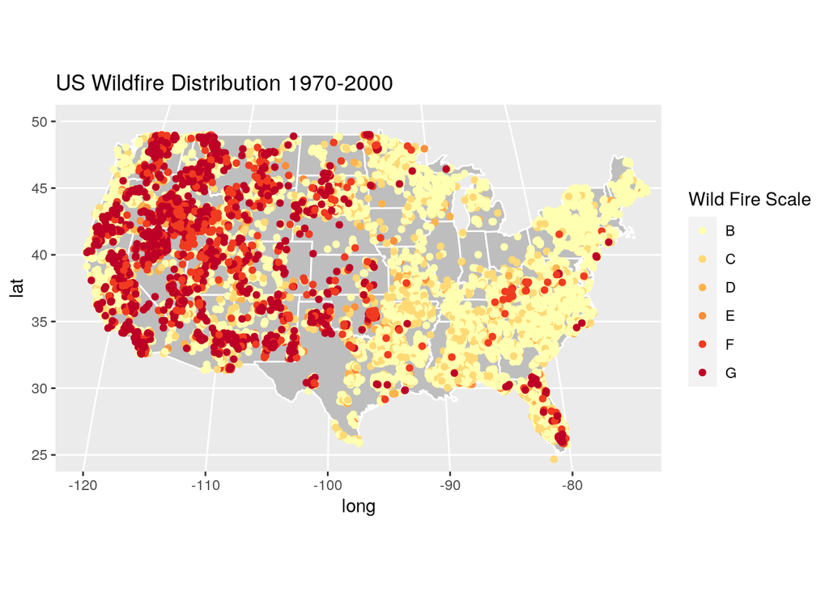

```r
ggplot() +
  geom_polygon(data=state, aes(x=long, y=lat, group=group), color = "white", fill = "grey") +
  geom_point(data = us_wildfire_clean[which(us_wildfire_clean$wstation_byear >= 1970 & us_wildfire_clean$wstation_byear < 2000),], aes(x=longitude, y = latitude, color = class_fac)) +
  scale_color_brewer(palette = "YlOrRd")+
  ggtitle("US Wildfire Distribution 1970-2000")+
  guides(color=guide_legend(title="Wild Fire Scale"))+
  coord_map(projection = "sinusoidal", xlim=c(-120, -75), ylim = c(25, 50))
```

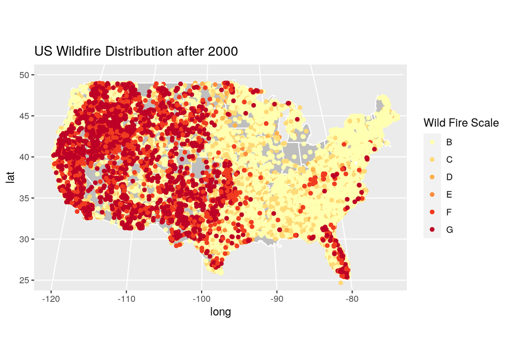

```r
ggplot() +
  geom_polygon(data=state, aes(x=long, y=lat, group=group), color = "white", fill = "grey") +
  geom_point(data = us_wildfire_clean[which(us_wildfire_clean$wstation_byear >= 200),], aes(x=longitude, y = latitude, color = class_fac)) +
  scale_color_brewer(palette = "YlOrRd")+
  ggtitle("US Wildfire Distribution after 2000")+
  guides(color=guide_legend(title="Wild Fire Scale"))+
  coord_map(projection = "sinusoidal", xlim=c(-120, -75), ylim = c(25, 50))
```

### 2.2.4 Density graph

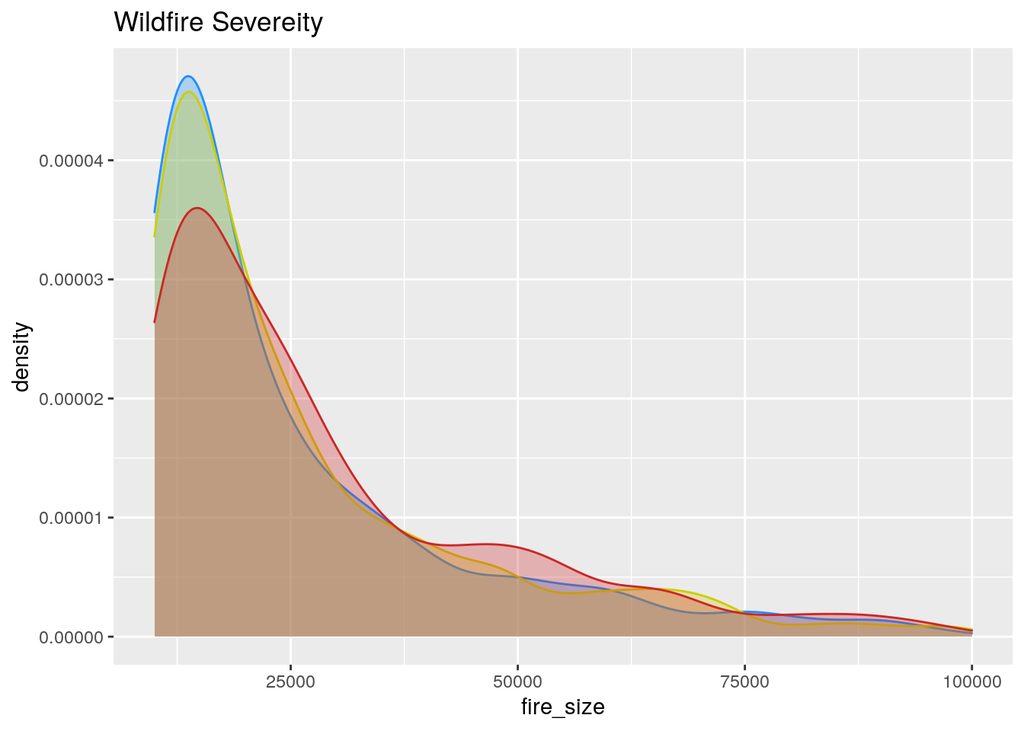

```r
ggplot() +
  geom_density(data= us_wildfire_clean[which(us_wildfire_clean$wstation_byear <= 1970 & us_wildfire_clean$fire_size > 100),], aes(x = fire_size, y=..density..),
               alpha=.3,
               colour="dodgerblue", fill="dodgerblue") +
  geom_density(data= us_wildfire_clean[which(us_wildfire_clean$wstation_byear >= 1970 & us_wildfire_clean$fire_size > 100 & us_wildfire_clean$wstation_byear < 2000),], aes(x = fire_size, y=..density..),
               alpha=.3,
               colour="yellow3", fill="yellow3") +
  geom_density(data= us_wildfire_clean[which(us_wildfire_clean$wstation_byear >= 2000 & us_wildfire_clean$fire_size > 100),], aes(x = fire_size, y=..density..),
               alpha=.3,
                 colour="firebrick3", fill="firebrick3") +
  xlim(10000, 100000) +
  ggtitle("Wildfire Severeity")
```

### 2.2.5 Exploring Missing Data and Correlation

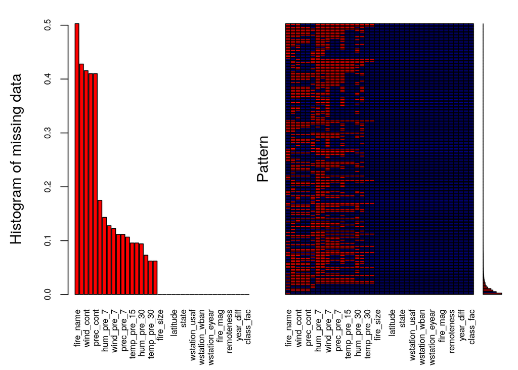

```
##
##  Variables sorted by number of missings:
##            Variable      Count
##           fire_name 0.50282019
##            hum_cont 0.42786638
##           wind_cont 0.41558884
##           temp_cont 0.41002139
##           prec_cont 0.41002139
##  vegetation_classed 0.17480307
##           hum_pre_7 0.14329476
##          hum_pre_15 0.12783234
##          wind_pre_7 0.12250802
##          temp_pre_7 0.11173782
##          prec_pre_7 0.11173782
##         wind_pre_15 0.10663231
##         temp_pre_15 0.09571623
##         prec_pre_15 0.09571623
##          hum_pre_30 0.09413595
##         wind_pre_30 0.07308179
##         temp_pre_30 0.06216571
##         prec_pre_30 0.06216571
##           fire_size 0.00000000
##     fire_size_class 0.00000000
##    stat_cause_descr 0.00000000
##            latitude 0.00000000
##           longitude 0.00000000
##               state 0.00000000
##       disc_pre_year 0.00000000
##       wstation_usaf 0.00000000
##          dstation_m 0.00000000
##       wstation_wban 0.00000000
##      wstation_byear 0.00000000
##      wstation_eyear 0.00000000
##          vegetation 0.00000000
##            fire_mag 0.00000000
##        weather_file 0.00000000
##          remoteness 0.00000000
##              region 0.00000000
##           year_diff 0.00000000
##              season 0.00000000
##           class_fac 0.00000000
```

```r
#missing data plot
aggr_plot <- aggr(us_wildfire_clean,
                  col = c('navyblue','red'),
                  numbers = TRUE,
                  sortVars = TRUE,
                  labels = names(us_wildfire_clean),
                  cex.axis = .7,
                  gap = 2,
                  ylab = c("Histogram of missing data","Pattern"))
```

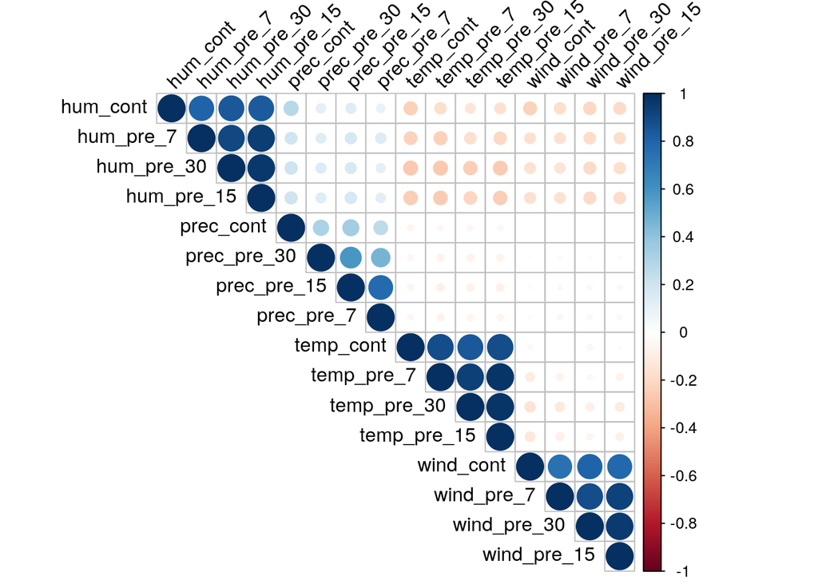

```r
#It is likely that weather columns are correlated. to investigate this we create a correlation matrix

#create a dataframe of weather
weather <- us_wildfire_clean %>%
  dplyr::select(temp_pre_30:prec_cont)

#create a correlation matrix (omitting NAs)
cor_matrix <- cor(weather, use = "complete.obs")

#create a visualization
corrplot(cor_matrix, type = "upper", order = "hclust",
         tl.col = "black", tl.srt = 45)
```

```r
#we can see that their is a strong correlation with each set of variables. i.e. temperature 7 days before the fire is correlated with temp 30 days before the fire.
```

## 2.3 Model Preparation

### 2.3.1 Splitting Data

We split our data into 80% training and 20% testing data. Because fire size is heavily skewed towards smaller fires, we used stratified sampling.

```r
#first we make a dataframe containing only variables we want to use in our models
fire_modeling_df <- us_wildfire_clean %>%
  dplyr::select(-fire_name, #remove fire name
         -fire_size_class, #remove fire size class
         -class_fac, #which is also a size class
         -state, #because we have regions
         -disc_pre_year, #because we have year_diff to represent year
         -wstation_usaf, #remove weather station name
         -wstation_wban, #remove this (not described in codebook)
         -wstation_byear, #remove station year installed
         -wstation_eyear, #remove station year ended data recording
         -weather_file, #remove name of weather file
         -dstation_m, #remove distance of weather station to fire
         -vegetation #remove vegetaiton because we already have it classed
         )

#define split parameters
us_wildfire_split <- fire_modeling_df %>%
  initial_split(prop = 0.8, strata = "fire_size")

#write split data to data frames
fire_train <- training(us_wildfire_split)
fire_test <- testing(us_wildfire_split)

#set up folds in training data for cross validation
train_folds <- vfold_cv(fire_train, v = 10, repeats = 5)
```

### 2.3.2 Imputing Missing Data

```r
#select weather cols
weather_train <- fire_train %>%
  select(temp_pre_30:prec_cont)

weather_test <- fire_test %>%
  select(temp_pre_30:prec_cont)

#select cols not in weather
notweather_train <- fire_train %>%
  select(-colnames(weather_train))

notweather_test <- fire_test %>%
  select(-colnames(weather_test))

#imputation of weather data
weather_train_imputed <- imputePCA(weather_train, ncp=4)


weather_test_imputed <- imputePCA(weather_test, ncp=4)
```

### 2.3.3 Principle Components

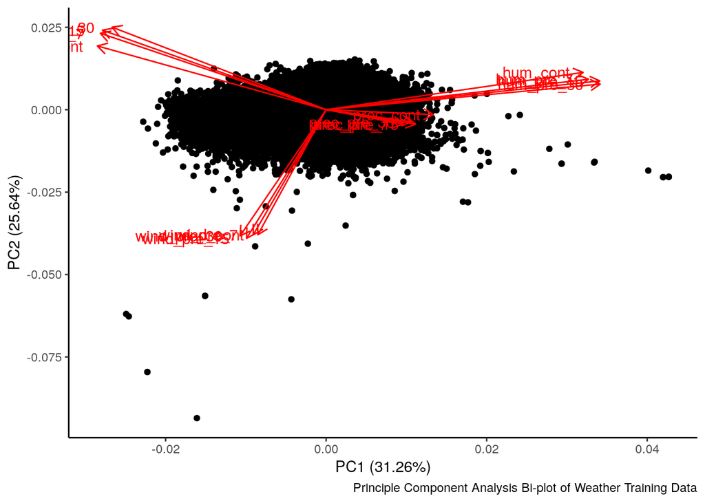

```r
#Do PCA on both test and train data separately
weather_train_PCA <- weather_train_imputed$completeObs %>%
  scale(center = T, scale = T) %>%  #first scale and center the data
  prcomp(rank. = 4) #do PCA


#weather_train_PCA$x

#Do PCA on both test and train data separately
weather_test_PCA <- weather_test_imputed$completeObs %>%
  scale(center = T, scale = T) %>%  #first scale and center the data
  prcomp(rank. = 4)

#Make a PCA bi-plot
autoplot(weather_train_PCA,
         data = weather_train,
         loadings = TRUE,
         loadings.label = TRUE,
         loadings.label.hjust = 1.2) +
  theme_classic() +
  labs(caption = "Principle Component Analysis Bi-plot of Weather Training Data")
```

```r
#put data back together

#bind imputed weather data to rest of rows
fire_train_complete <- cbind(notweather_train, weather_train_PCA$x) %>%
  na.omit()

fire_test_complete <- cbind(notweather_test, weather_test_PCA$x) %>%
  na.omit()
```

## 2.4 Modeling As a Regression Problem

### 2.4.1 Linear regression for each region

```r
lm_whole = lm(fire_size ~ PC1 + PC2 + PC3 + PC4 + year_diff + remoteness + vegetation_classed + stat_cause_descr, data = fire_train_complete)
summary(lm_whole) %>% pander
```

Table continues below

|  | Estimate | Std. Error | t value |
| --- | --- | --- | --- |
| **(Intercept)** | 3479 | 386.2 | 9.009 |
| **PC1** | -776.3 | 38.71 | -20.05 |
| **PC2** | -137.7 | 38.73 | -3.557 |
| **PC3** | 135.7 | 43.91 | 3.089 |
| **PC4** | -599.8 | 55.41 | -10.83 |
| **year_diff** | 60.03 | 12.21 | 4.915 |
| **remoteness** | -9364 | 631 | -14.84 |
| **vegetation_classedDesert** | -1116 | 682.8 | -1.634 |
| **vegetation_classedOpen Shrubland** | -1396 | 309.7 | -4.507 |
| **vegetation_classedPolar Desert/Rock/Ice** | -633.6 | 306.8 | -2.065 |
| **vegetation_classedSecondary Tropical Evergreen Broadleaf Forest** | -1693 | 314.3 | -5.388 |
| **vegetation_classedTemperate Evergreen Needleleaf Forest TmpENF** | -277.4 | 612.2 | -0.453 |
| **stat_cause_descrCampfire** | 2090 | 522.5 | 4 |
| **stat_cause_descrChildren** | -649 | 514.8 | -1.261 |
| **stat_cause_descrDebris Burning** | -243.9 | 234.2 | -1.042 |
| **stat_cause_descrEquipment Use** | 577.3 | 334.5 | 1.726 |
| **stat_cause_descrFireworks** | -1440 | 1218 | -1.183 |
| **stat_cause_descrLightning** | 4978 | 298 | 16.7 |
| **stat_cause_descrMiscellaneous** | 267.2 | 271.2 | 0.9854 |
| **stat_cause_descrMissing/Undefined** | 516.4 | 326.9 | 1.579 |
| **stat_cause_descrPowerline** | 971.8 | 760.9 | 1.277 |
| **stat_cause_descrRailroad** | -113.4 | 584.4 | -0.194 |
| **stat_cause_descrSmoking** | -641 | 547.1 | -1.172 |
| **stat_cause_descrStructure** | -635.4 | 1972 | -0.3222 |

|  | Pr(>\|t\|) |
| --- | --- |
| **(Intercept)** | 0.0000000000000000002214 |
| **PC1** | 0.00000000000000000000000000000000000000000000000000000000000000000000000000000000000000008317 |
| **PC2** | 0.0003764 |
| **PC3** | 0.00201 |
| **PC4** | 0.000000000000000000000000002977 |
| **year_diff** | 0.000000894 |
| **remoteness** | 0.000000000000000000000000000000000000000000000000125 |
| **vegetation_classedDesert** | 0.1023 |
| **vegetation_classedOpen Shrubland** | 0.000006594 |
| **vegetation_classedPolar Desert/Rock/Ice** | 0.03892 |
| **vegetation_classedSecondary Tropical Evergreen Broadleaf Forest** | 0.0000000717 |
| **vegetation_classedTemperate Evergreen Needleleaf Forest TmpENF** | 0.6505 |
| **stat_cause_descrCampfire** | 0.00006338 |
| **stat_cause_descrChildren** | 0.2075 |
| **stat_cause_descrDebris Burning** | 0.2976 |
| **stat_cause_descrEquipment Use** | 0.08441 |
| **stat_cause_descrFireworks** | 0.2369 |
| **stat_cause_descrLightning** | 0.00000000000000000000000000000000000000000000000000000000000002494 |
| **stat_cause_descrMiscellaneous** | 0.3245 |
| **stat_cause_descrMissing/Undefined** | 0.1142 |
| **stat_cause_descrPowerline** | 0.2016 |
| **stat_cause_descrRailroad** | 0.8461 |
| **stat_cause_descrSmoking** | 0.2414 |
| **stat_cause_descrStructure** | 0.7473 |

Fitting linear model: fire_size ~ PC1 + PC2 + PC3 + PC4 + year_diff + remoteness + vegetation_classed + stat_cause_descr

| Observations | Residual Std. Error | $R^2$ | Adjusted $R^2$ |
| --- | --- | --- | --- |
| 27229 | 12405 | 0.06151 | 0.06072 |

```r
lm_whole2 <- update(lm_whole, . ~ . - stat_cause_descr)
summary(lm_whole2) %>% pander
```

Table continues below

|  | Estimate | Std. Error | t value |
| --- | --- | --- | --- |
| **(Intercept)** | 5068 | 345.9 | 14.65 |
| **PC1** | -1062 | 35.77 | -29.68 |
| **PC2** | -5.831 | 38.38 | -0.1519 |
| **PC3** | 44.83 | 43.91 | 1.021 |
| **PC4** | -627 | 55.42 | -11.31 |
| **year_diff** | 64.25 | 12.06 | 5.327 |
| **remoteness** | -9112 | 632.6 | -14.4 |
| **vegetation_classedDesert** | -1585 | 687 | -2.308 |
| **vegetation_classedOpen Shrubland** | -2583 | 304.4 | -8.486 |
| **vegetation_classedPolar Desert/Rock/Ice** | -1126 | 307.5 | -3.663 |
| **vegetation_classedSecondary Tropical Evergreen Broadleaf Forest** | -2958 | 308.2 | -9.598 |
| **vegetation_classedTemperate Evergreen Needleleaf Forest TmpENF** | -359.6 | 616.5 | -0.5833 |

|  | Pr(>\|t\|) |
| --- | --- |
| **(Intercept)** | 0.000000000000000000000000000000000000000000000002028 |
| **PC1** | 1.609e-190 |
| **PC2** | 0.8792 |
| **PC3** | 0.3073 |
| **PC4** | 0.00000000000000000000000000001319 |
| **year_diff** | 0.0000001008 |
| **remoteness** | 0.0000000000000000000000000000000000000000000000728 |
| **vegetation_classedDesert** | 0.02103 |
| **vegetation_classedOpen Shrubland** | 0.00000000000000002247 |
| **vegetation_classedPolar Desert/Rock/Ice** | 0.0002502 |
| **vegetation_classedSecondary Tropical Evergreen Broadleaf Forest** | 0.0000000000000000000008819 |
| **vegetation_classedTemperate Evergreen Needleleaf Forest TmpENF** | 0.5597 |

Fitting linear model: fire_size ~ PC1 + PC2 + PC3 + PC4 + year_diff + remoteness + vegetation_classed

| Observations | Residual Std. Error | $R^2$ | Adjusted $R^2$ |
| --- | --- | --- | --- |
| 27229 | 12502 | 0.0464 | 0.04602 |

```r
lm_sw = lm(fire_size ~ PC1 + PC2 + PC3 + PC4 + year_diff + remoteness + vegetation_classed + stat_cause_descr, data = fire_train_complete[which(fire_train_complete$region == "SouthWest"),])
summary(lm_sw) %>% pander
```

Table continues below

|  | Estimate | Std. Error | t value |
| --- | --- | --- | --- |
| **(Intercept)** | 1533 | 1357 | 1.129 |
| **PC1** | -614.9 | 92.89 | -6.62 |
| **PC2** | -608.1 | 89.88 | -6.766 |
| **PC3** | 16.67 | 210.8 | 0.07906 |
| **PC4** | -677.7 | 168.9 | -4.013 |
| **year_diff** | 111.1 | 32.31 | 3.438 |
| **remoteness** | -8766 | 3743 | -2.342 |
| **vegetation_classedPolar Desert/Rock/Ice** | -146.3 | 621.1 | -0.2356 |
| **vegetation_classedSecondary Tropical Evergreen Broadleaf Forest** | -504.7 | 424.5 | -1.189 |
| **stat_cause_descrCampfire** | 7716 | 1496 | 5.159 |
| **stat_cause_descrChildren** | -1370 | 1709 | -0.8016 |
| **stat_cause_descrDebris Burning** | -123.4 | 666.8 | -0.1851 |
| **stat_cause_descrEquipment Use** | -609.6 | 805.4 | -0.7568 |
| **stat_cause_descrFireworks** | -1617 | 3341 | -0.484 |
| **stat_cause_descrLightning** | 2201 | 780.4 | 2.82 |
| **stat_cause_descrMiscellaneous** | 497.1 | 686.4 | 0.7241 |
| **stat_cause_descrMissing/Undefined** | 2822 | 913 | 3.091 |
| **stat_cause_descrPowerline** | 897.1 | 1228 | 0.7305 |
| **stat_cause_descrRailroad** | -836.6 | 2252 | -0.3714 |
| **stat_cause_descrSmoking** | -821.2 | 1357 | -0.6049 |
| **stat_cause_descrStructure** | 223.4 | 8070 | 0.02768 |

|  | Pr(>\|t\|) |
| --- | --- |
| **(Intercept)** | 0.2588 |
| **PC1** | 0.00000000003888 |
| **PC2** | 0.00000000001442 |
| **PC3** | 0.937 |
| **PC4** | 0.00006076 |
| **year_diff** | 0.0005896 |
| **remoteness** | 0.01922 |
| **vegetation_classedPolar Desert/Rock/Ice** | 0.8138 |
| **vegetation_classedSecondary Tropical Evergreen Broadleaf Forest** | 0.2345 |
| **stat_cause_descrCampfire** | 0.0000002556 |
| **stat_cause_descrChildren** | 0.4228 |
| **stat_cause_descrDebris Burning** | 0.8532 |
| **stat_cause_descrEquipment Use** | 0.4492 |
| **stat_cause_descrFireworks** | 0.6284 |
| **stat_cause_descrLightning** | 0.004814 |
| **stat_cause_descrMiscellaneous** | 0.469 |
| **stat_cause_descrMissing/Undefined** | 0.002006 |
| **stat_cause_descrPowerline** | 0.4651 |
| **stat_cause_descrRailroad** | 0.7103 |
| **stat_cause_descrSmoking** | 0.5452 |
| **stat_cause_descrStructure** | 0.9779 |

Fitting linear model: fire_size ~ PC1 + PC2 + PC3 + PC4 + year_diff + remoteness + vegetation_classed + stat_cause_descr

| Observations | Residual Std. Error | $R^2$ | Adjusted $R^2$ |
| --- | --- | --- | --- |
| 6326 | 13938 | 0.03939 | 0.03634 |

```r
lm_sw2 <- update(lm_sw, . ~ . - stat_cause_descr - PC2 - remoteness)
summary(lm_sw2) %>% pander
```

Table continues below

|  | Estimate | Std. Error | t value |
| --- | --- | --- | --- |
| **(Intercept)** | -451.6 | 570.2 | -0.792 |
| **PC1** | -715.1 | 82.59 | -8.659 |
| **PC3** | 256.2 | 207 | 1.237 |
| **PC4** | -600.3 | 166 | -3.616 |
| **year_diff** | 92.57 | 31.1 | 2.977 |
| **vegetation_classedPolar Desert/Rock/Ice** | 1153 | 584.1 | 1.974 |
| **vegetation_classedSecondary Tropical Evergreen Broadleaf Forest** | 91.81 | 410.8 | 0.2235 |

|  | Pr(>\|t\|) |
| --- | --- |
| **(Intercept)** | 0.4284 |
| **PC1** | 0.000000000000000005989 |
| **PC3** | 0.216 |
| **PC4** | 0.0003012 |
| **year_diff** | 0.002926 |
| **vegetation_classedPolar Desert/Rock/Ice** | 0.04838 |
| **vegetation_classedSecondary Tropical Evergreen Broadleaf Forest** | 0.8231 |

Fitting linear model: fire_size ~ PC1 + PC3 + PC4 + year_diff + vegetation_classed

| Observations | Residual Std. Error | $R^2$ | Adjusted $R^2$ |
| --- | --- | --- | --- |
| 6326 | 14040 | 0.0231 | 0.02217 |

```r
lm_se = lm(fire_size ~ PC1 + PC2 + PC3 + PC4 + year_diff + remoteness + vegetation_classed + stat_cause_descr, data = fire_train_complete[which(fire_train_complete$region == "SouthEast"),])
summary(lm_se) %>% pander
```

Table continues below

|  | Estimate | Std. Error | t value |
| --- | --- | --- | --- |
| **(Intercept)** | -2513 | 2241 | -1.121 |
| **PC1** | -39.35 | 29.38 | -1.34 |
| **PC2** | -66.19 | 21.04 | -3.146 |
| **PC3** | 41.17 | 17.79 | 2.314 |
| **PC4** | -19.53 | 31.4 | -0.6219 |
| **year_diff** | 2.39 | 5.862 | 0.4078 |
| **remoteness** | 19539 | 468.8 | 41.67 |
| **vegetation_classedOpen Shrubland** | -955 | 2240 | -0.4263 |
| **vegetation_classedPolar Desert/Rock/Ice** | -726.8 | 2242 | -0.3242 |
| **vegetation_classedSecondary Tropical Evergreen Broadleaf Forest** | -823.9 | 2240 | -0.3678 |
| **stat_cause_descrCampfire** | 18.91 | 238 | 0.07945 |
| **stat_cause_descrChildren** | 635.3 | 218.4 | 2.909 |
| **stat_cause_descrDebris Burning** | 227.7 | 91.93 | 2.477 |
| **stat_cause_descrEquipment Use** | 426.1 | 161.3 | 2.641 |
| **stat_cause_descrFireworks** | 268.1 | 1041 | 0.2577 |
| **stat_cause_descrLightning** | 1358 | 156.8 | 8.66 |
| **stat_cause_descrMiscellaneous** | 258.4 | 134.9 | 1.916 |
| **stat_cause_descrMissing/Undefined** | 242.2 | 149.5 | 1.62 |
| **stat_cause_descrPowerline** | 292.9 | 918.3 | 0.319 |
| **stat_cause_descrRailroad** | 575.4 | 219.9 | 2.617 |
| **stat_cause_descrSmoking** | 343.5 | 248.8 | 1.381 |
| **stat_cause_descrStructure** | 168.4 | 894 | 0.1884 |

|  | Pr(>\|t\|) |
| --- | --- |
| **(Intercept)** | 0.2623 |
| **PC1** | 0.1804 |
| **PC2** | 0.001662 |
| **PC3** | 0.0207 |
| **PC4** | 0.534 |
| **year_diff** | 0.6835 |
| **remoteness** | 0 |
| **vegetation_classedOpen Shrubland** | 0.6699 |
| **vegetation_classedPolar Desert/Rock/Ice** | 0.7458 |
| **vegetation_classedSecondary Tropical Evergreen Broadleaf Forest** | 0.713 |
| **stat_cause_descrCampfire** | 0.9367 |
| **stat_cause_descrChildren** | 0.003634 |
| **stat_cause_descrDebris Burning** | 0.01325 |
| **stat_cause_descrEquipment Use** | 0.008266 |
| **stat_cause_descrFireworks** | 0.7967 |
| **stat_cause_descrLightning** | 0.000000000000000005298 |
| **stat_cause_descrMiscellaneous** | 0.05545 |
| **stat_cause_descrMissing/Undefined** | 0.1052 |
| **stat_cause_descrPowerline** | 0.7498 |
| **stat_cause_descrRailroad** | 0.008878 |
| **stat_cause_descrSmoking** | 0.1674 |
| **stat_cause_descrStructure** | 0.8506 |

Fitting linear model: fire_size ~ PC1 + PC2 + PC3 + PC4 + year_diff + remoteness + vegetation_classed + stat_cause_descr

| Observations | Residual Std. Error | $R^2$ | Adjusted $R^2$ |
| --- | --- | --- | --- |
| 12420 | 3878 | 0.1363 | 0.1349 |

```r
lm_se2 <- update(lm_se, . ~ . - stat_cause_descr - PC1 - PC4- year_diff - vegetation_classed)
summary(lm_se2) %>% pander
```

|  | Estimate | Std. Error | t value | Pr(>\|t\|) |
| --- | --- | --- | --- | --- |
| **(Intercept)** | -3170 | 87.4 | -36.27 | 7.704e-274 |
| **PC2** | -33.67 | 19.94 | -1.689 | 0.09134 |
| **PC3** | 31.52 | 16.36 | 1.927 | 0.05398 |
| **remoteness** | 19712 | 458.2 | 43.02 | 0 |

Fitting linear model: fire_size ~ PC2 + PC3 + remoteness

| Observations | Residual Std. Error | $R^2$ | Adjusted $R^2$ |
| --- | --- | --- | --- |
| 12420 | 3890 | 0.1298 | 0.1296 |

```r
lm_me = lm(fire_size ~ PC1 + PC2 + PC3 + PC4 + year_diff + remoteness + vegetation_classed + stat_cause_descr, data = fire_train_complete[which(fire_train_complete$region == "MidWest"),])
summary(lm_me) %>% pander
```

Table continues below

|  | Estimate | Std. Error | t value |
| --- | --- | --- | --- |
| **(Intercept)** | 4209 | 548.8 | 7.668 |
| **PC1** | -384.9 | 57.72 | -6.67 |
| **PC2** | -118.3 | 46.16 | -2.562 |
| **PC3** | 74.11 | 51.91 | 1.428 |
| **PC4** | -195.5 | 76.26 | -2.563 |
| **year_diff** | 8.26 | 13.92 | 0.5933 |
| **remoteness** | -15258 | 1846 | -8.265 |
| **vegetation_classedDesert** | -328 | 544.9 | -0.6019 |
| **vegetation_classedPolar Desert/Rock/Ice** | 209.4 | 183 | 1.144 |
| **vegetation_classedSecondary Tropical Evergreen Broadleaf Forest** | 1161 | 874.2 | 1.328 |
| **vegetation_classedTemperate Evergreen Needleleaf Forest TmpENF** | 2727 | 507.3 | 5.376 |
| **stat_cause_descrCampfire** | 201.1 | 507.3 | 0.3964 |
| **stat_cause_descrChildren** | -237.1 | 420.6 | -0.5637 |
| **stat_cause_descrDebris Burning** | -314.8 | 260.1 | -1.21 |
| **stat_cause_descrEquipment Use** | -249.2 | 342 | -0.7285 |
| **stat_cause_descrFireworks** | -20.58 | 692 | -0.02975 |
| **stat_cause_descrLightning** | 2348 | 380.9 | 6.163 |
| **stat_cause_descrMiscellaneous** | -135.2 | 288.2 | -0.4693 |
| **stat_cause_descrMissing/Undefined** | 313.4 | 412 | 0.7607 |
| **stat_cause_descrPowerline** | 1460 | 794.3 | 1.838 |
| **stat_cause_descrRailroad** | -573.3 | 599.8 | -0.9558 |
| **stat_cause_descrSmoking** | -621.6 | 600 | -1.036 |
| **stat_cause_descrStructure** | -484.6 | 1374 | -0.3526 |

|  | Pr(>\|t\|) |
| --- | --- |
| **(Intercept)** | 0.00000000000002511 |
| **PC1** | 0.00000000003168 |
| **PC2** | 0.01046 |
| **PC3** | 0.1535 |
| **PC4** | 0.01043 |
| **year_diff** | 0.553 |
| **remoteness** | 0.0000000000000002281 |
| **vegetation_classedDesert** | 0.5473 |
| **vegetation_classedPolar Desert/Rock/Ice** | 0.2526 |
| **vegetation_classedSecondary Tropical Evergreen Broadleaf Forest** | 0.1845 |
| **vegetation_classedTemperate Evergreen Needleleaf Forest TmpENF** | 0.00000008365 |
| **stat_cause_descrCampfire** | 0.6918 |
| **stat_cause_descrChildren** | 0.573 |
| **stat_cause_descrDebris Burning** | 0.2262 |
| **stat_cause_descrEquipment Use** | 0.4664 |
| **stat_cause_descrFireworks** | 0.9763 |
| **stat_cause_descrLightning** | 0.0000000008322 |
| **stat_cause_descrMiscellaneous** | 0.6389 |
| **stat_cause_descrMissing/Undefined** | 0.4469 |
| **stat_cause_descrPowerline** | 0.06612 |
| **stat_cause_descrRailroad** | 0.3393 |
| **stat_cause_descrSmoking** | 0.3003 |
| **stat_cause_descrStructure** | 0.7244 |

Fitting linear model: fire_size ~ PC1 + PC2 + PC3 + PC4 + year_diff + remoteness + vegetation_classed + stat_cause_descr

| Observations | Residual Std. Error | $R^2$ | Adjusted $R^2$ |
| --- | --- | --- | --- |
| 2442 | 4054 | 0.09542 | 0.08719 |

```r
lm_me2 <- update(lm_me, . ~ . - stat_cause_descr - PC3 - year_diff - PC2)
summary(lm_me2) %>% pander
```

Table continues below

|  | Estimate | Std. Error | t value |
| --- | --- | --- | --- |
| **(Intercept)** | 4329 | 477.4 | 9.068 |
| **PC1** | -503.9 | 51.22 | -9.838 |
| **PC4** | -149.5 | 72.39 | -2.066 |
| **remoteness** | -13396 | 1804 | -7.427 |
| **vegetation_classedDesert** | -381 | 545.1 | -0.6989 |
| **vegetation_classedPolar Desert/Rock/Ice** | 185.1 | 180.8 | 1.024 |
| **vegetation_classedSecondary Tropical Evergreen Broadleaf Forest** | 812.7 | 869.6 | 0.9346 |
| **vegetation_classedTemperate Evergreen Needleleaf Forest TmpENF** | 3101 | 505.9 | 6.131 |

|  | Pr(>\|t\|) |
| --- | --- |
| **(Intercept)** | 0.0000000000000000002438 |
| **PC1** | 0.0000000000000000000002007 |
| **PC4** | 0.03896 |
| **remoteness** | 0.0000000000001528 |
| **vegetation_classedDesert** | 0.4847 |
| **vegetation_classedPolar Desert/Rock/Ice** | 0.3061 |
| **vegetation_classedSecondary Tropical Evergreen Broadleaf Forest** | 0.3501 |
| **vegetation_classedTemperate Evergreen Needleleaf Forest TmpENF** | 0.000000001018 |

Fitting linear model: fire_size ~ PC1 + PC4 + remoteness + vegetation_classed

| Observations | Residual Std. Error | $R^2$ | Adjusted $R^2$ |
| --- | --- | --- | --- |
| 2442 | 4101 | 0.06889 | 0.06621 |

```r
lm_w = lm(fire_size ~ PC1 + PC2 + PC3 + PC4 + year_diff + remoteness + vegetation_classed + stat_cause_descr, data = fire_train_complete[which(fire_train_complete$region == "West"),])
summary(lm_w) %>% pander
```

Table continues below

|  | Estimate | Std. Error | t value |
| --- | --- | --- | --- |
| **(Intercept)** | 18251 | 2013 | 9.066 |
| **PC1** | -430.3 | 205.8 | -2.091 |
| **PC2** | 618 | 234 | 2.641 |
| **PC3** | 394 | 567.2 | 0.6947 |
| **PC4** | 448.2 | 386.2 | 1.161 |
| **year_diff** | 191 | 54.42 | 3.509 |
| **remoteness** | -44907 | 2174 | -20.65 |
| **vegetation_classedDesert** | -1220 | 1602 | -0.7619 |
| **vegetation_classedOpen Shrubland** | 2287 | 2677 | 0.8545 |
| **vegetation_classedPolar Desert/Rock/Ice** | -206.9 | 904.2 | -0.2288 |
| **vegetation_classedSecondary Tropical Evergreen Broadleaf Forest** | 664.4 | 1380 | 0.4813 |
| **vegetation_classedTemperate Evergreen Needleleaf Forest TmpENF** | -1070 | 1706 | -0.6272 |
| **stat_cause_descrCampfire** | 2662 | 2613 | 1.019 |
| **stat_cause_descrChildren** | -226.2 | 2936 | -0.07705 |
| **stat_cause_descrDebris Burning** | 141.6 | 2011 | 0.0704 |
| **stat_cause_descrEquipment Use** | 1368 | 1877 | 0.7291 |
| **stat_cause_descrFireworks** | -3313 | 4275 | -0.7749 |
| **stat_cause_descrLightning** | 1941 | 1635 | 1.187 |
| **stat_cause_descrMiscellaneous** | -618 | 1771 | -0.3489 |
| **stat_cause_descrMissing/Undefined** | -2598 | 1975 | -1.316 |
| **stat_cause_descrPowerline** | -970.7 | 3398 | -0.2857 |
| **stat_cause_descrRailroad** | -1649 | 3868 | -0.4264 |
| **stat_cause_descrSmoking** | -125.5 | 3331 | -0.03767 |
| **stat_cause_descrStructure** | -3756 | 8487 | -0.4425 |

|  | Pr(>\|t\|) |
| --- | --- |
| **(Intercept)** | 0.0000000000000000001833 |
| **PC1** | 0.03657 |
| **PC2** | 0.008305 |
| **PC3** | 0.4873 |
| **PC4** | 0.2459 |
| **year_diff** | 0.0004545 |
| **remoteness** | 0.000000000000000000000000000000000000000000000000000000000000000000000000000000000000000001829 |
| **vegetation_classedDesert** | 0.4462 |
| **vegetation_classedOpen Shrubland** | 0.3929 |
| **vegetation_classedPolar Desert/Rock/Ice** | 0.819 |
| **vegetation_classedSecondary Tropical Evergreen Broadleaf Forest** | 0.6303 |
| **vegetation_classedTemperate Evergreen Needleleaf Forest TmpENF** | 0.5306 |
| **stat_cause_descrCampfire** | 0.3083 |
| **stat_cause_descrChildren** | 0.9386 |
| **stat_cause_descrDebris Burning** | 0.9439 |
| **stat_cause_descrEquipment Use** | 0.466 |
| **stat_cause_descrFireworks** | 0.4385 |
| **stat_cause_descrLightning** | 0.2353 |
| **stat_cause_descrMiscellaneous** | 0.7271 |
| **stat_cause_descrMissing/Undefined** | 0.1884 |
| **stat_cause_descrPowerline** | 0.7752 |
| **stat_cause_descrRailroad** | 0.6699 |
| **stat_cause_descrSmoking** | 0.9699 |
| **stat_cause_descrStructure** | 0.6581 |

Fitting linear model: fire_size ~ PC1 + PC2 + PC3 + PC4 + year_diff + remoteness + vegetation_classed + stat_cause_descr

| Observations | Residual Std. Error | $R^2$ | Adjusted $R^2$ |
| --- | --- | --- | --- |
| 4352 | 23592 | 0.1273 | 0.1227 |

```r
lm_w2 <- update(lm_w, . ~ . - stat_cause_descr - PC3 - PC4 - vegetation_classed)
summary(lm_w2) %>% pander
```

Table continues below

|  | Estimate | Std. Error | t value |
| --- | --- | --- | --- |
| **(Intercept)** | 19277 | 1158 | 16.65 |
| **PC1** | -364.1 | 158.9 | -2.291 |
| **PC2** | 637.5 | 200.1 | 3.186 |
| **year_diff** | 186.3 | 53.71 | 3.468 |
| **remoteness** | -46229 | 2047 | -22.58 |

|  | Pr(>\|t\|) |
| --- | --- |
| **(Intercept)** | 0.000000000000000000000000000000000000000000000000000000000002299 |
| **PC1** | 0.022 |
| **PC2** | 0.001452 |
| **year_diff** | 0.0005291 |
| **remoteness** | 7.264e-107 |

Fitting linear model: fire_size ~ PC1 + PC2 + year_diff + remoteness

| Observations | Residual Std. Error | $R^2$ | Adjusted $R^2$ |
| --- | --- | --- | --- |
| 4352 | 23593 | 0.1234 | 0.1226 |

```r
lm_ne = lm(fire_size ~ PC1 + PC2 + PC3 + PC4 + year_diff + remoteness + vegetation_classed + stat_cause_descr, data = fire_train_complete[which(fire_train_complete$region == "NorthEast"),])
summary(lm_ne) %>% pander
```

Table continues below

|  | Estimate | Std. Error | t value |
| --- | --- | --- | --- |
| **(Intercept)** | -46.72 | 47.27 | -0.9884 |
| **PC1** | -11.38 | 9.196 | -1.237 |
| **PC2** | -9.431 | 6.176 | -1.527 |
| **PC3** | -6.782 | 5.752 | -1.179 |
| **PC4** | 10.73 | 9.761 | 1.099 |
| **year_diff** | 0.5557 | 2.002 | 0.2775 |
| **remoteness** | 1132 | 69.54 | 16.28 |
| **vegetation_classedDesert** | -24.33 | 67.02 | -0.3631 |
| **vegetation_classedOpen Shrubland** | -87.43 | 80.46 | -1.087 |
| **vegetation_classedPolar Desert/Rock/Ice** | 26.36 | 26.21 | 1.006 |
| **vegetation_classedTemperate Evergreen Needleleaf Forest TmpENF** | 5.826 | 35.97 | 0.162 |
| **stat_cause_descrCampfire** | -27.26 | 64.16 | -0.425 |
| **stat_cause_descrChildren** | -28.82 | 82.97 | -0.3474 |
| **stat_cause_descrDebris Burning** | -35.04 | 39.67 | -0.8833 |
| **stat_cause_descrEquipment Use** | -30.7 | 67.41 | -0.4555 |
| **stat_cause_descrFireworks** | -3.143 | 411.4 | -0.007641 |
| **stat_cause_descrLightning** | -29.71 | 62.79 | -0.4732 |
| **stat_cause_descrMiscellaneous** | -38.33 | 33.96 | -1.129 |
| **stat_cause_descrMissing/Undefined** | 34.69 | 65.41 | 0.5304 |
| **stat_cause_descrPowerline** | -40.74 | 122.2 | -0.3334 |
| **stat_cause_descrRailroad** | -21.1 | 121.9 | -0.1731 |
| **stat_cause_descrSmoking** | -39.8 | 56.33 | -0.7065 |
| **stat_cause_descrStructure** | -29.27 | 411.3 | -0.07117 |

|  | Pr(>\|t\|) |
| --- | --- |
| **(Intercept)** | 0.3231 |
| **PC1** | 0.2163 |
| **PC2** | 0.1269 |
| **PC3** | 0.2385 |
| **PC4** | 0.272 |
| **year_diff** | 0.7814 |
| **remoteness** | 0.0000000000000000000000000000000000000000000000000000002025 |
| **vegetation_classedDesert** | 0.7166 |
| **vegetation_classedOpen Shrubland** | 0.2774 |
| **vegetation_classedPolar Desert/Rock/Ice** | 0.3146 |
| **vegetation_classedTemperate Evergreen Needleleaf Forest TmpENF** | 0.8713 |
| **stat_cause_descrCampfire** | 0.6709 |
| **stat_cause_descrChildren** | 0.7284 |
| **stat_cause_descrDebris Burning** | 0.3772 |
| **stat_cause_descrEquipment Use** | 0.6488 |
| **stat_cause_descrFireworks** | 0.9939 |
| **stat_cause_descrLightning** | 0.6361 |
| **stat_cause_descrMiscellaneous** | 0.2592 |
| **stat_cause_descrMissing/Undefined** | 0.5959 |
| **stat_cause_descrPowerline** | 0.7389 |
| **stat_cause_descrRailroad** | 0.8626 |
| **stat_cause_descrSmoking** | 0.48 |
| **stat_cause_descrStructure** | 0.9433 |

Fitting linear model: fire_size ~ PC1 + PC2 + PC3 + PC4 + year_diff + remoteness + vegetation_classed + stat_cause_descr

| Observations | Residual Std. Error | $R^2$ | Adjusted $R^2$ |
| --- | --- | --- | --- |
| 1689 | 409.1 | 0.1589 | 0.1478 |

```r
lm_ne2 <- update(lm_ne, . ~ . - stat_cause_descr - vegetation_classed - year_diff - PC4 - PC3 - PC2)
summary(lm_ne2) %>% pander
```

Table continues below

|  | Estimate | Std. Error | t value |
| --- | --- | --- | --- |
| **(Intercept)** | -42.51 | 13.64 | -3.116 |
| **PC1** | -11.98 | 6.932 | -1.728 |
| **remoteness** | 1100 | 64.7 | 17 |

|  | Pr(>\|t\|) |
| --- | --- |
| **(Intercept)** | 0.001861 |
| **PC1** | 0.0841 |
| **remoteness** | 0.000000000000000000000000000000000000000000000000000000000006434 |

Fitting linear model: fire_size ~ PC1 + remoteness

| Observations | Residual Std. Error | $R^2$ | Adjusted $R^2$ |
| --- | --- | --- | --- |
| 1689 | 407.8 | 0.1545 | 0.1535 |

### 2.4.2 K Nearest Neighbor

KNN (short for K Nearest Neighbor) is a non-linear algorithm that works for both classification and regression problems. The basic premise behind the model is that it predicts the dependent variable based on how similar they are to other observations where the dependent variable is known.

KNN works by calculating euclidean distance between observations, so all inputs have to be numeric. Therefore, we have to do some pre-model data changes to our training and test sets. For both test data and training data we dummy code categorical variables, then we center and scale the data. As before, we assume that the training and test data are completely separated, so we process the two data sets separately.

```r
#first we dummy code categorical variables (what about ordinal?)
knn_ready_train <- dummy_cols(fire_train_complete, select_columns =
                                c("stat_cause_descr", "region", "vegetation_classed", "season")) %>%
  #then we get rid of non-dummy coded variables
  select(-stat_cause_descr, - region, - vegetation_classed, -season) %>%
  #then convert back to a data frame (as output for `dummy_cols` is a matrix)
  as.data.frame()

#then we center and scale the data, except our outcome
knn_ready_train[,-1] <- scale(knn_ready_train[,-1], center = T, scale = T)


#of course our next step is to do the same to the test data
knn_ready_test <- dummy_cols(fire_test_complete,
                             select_columns = c("stat_cause_descr", "region", "vegetation_classed", "season")) %>%
  select(-stat_cause_descr, - region, - vegetation_classed, -season) %>%
  as.data.frame()

knn_ready_test[,-1] <- scale(knn_ready_test[,-1], center = T, scale = T)
```

Next we split up the training and test data into a data frame that has only independent variables and a data frame that has only dependent variables (in this case `fire_size`). We do this for both the test and the training data.

```r
#YTrain is the true values for fire size on the training set
YTrain = knn_ready_train$fire_size

#XTrain is the design matrix for training data
XTrain =  knn_ready_train %>%
  select(-fire_size)

#YTest is the true value for fire_size on the test set
YTest = knn_ready_test$fire_size

#Xtest is the design matrix for test data
XTest = knn_ready_test %>%
  select(-fire_size)
```

Then we use Leave One Out Cross Validation to determine the best number of neighbors to consider. A low number of neighbors considered results in a highly flexible model, while a higher number results in a less flexible model. For this process we built a function which we enter a starting value of K, an ending value of K, and the sampling interval. The result is a data frame of MSE values for each value of K that we test. This process is computationally intensive so we automatically saved results to a csv.

```r
#make a function that saves KNN LOOCV results for different values of K
knn_loocv <- function(startk, endk, interval)
  {

#set up possible number of nearest neighbors to be considered
allK = seq(from = startk, to = endk, by = interval)

#create a vector of the same length to save the MSE in later
k_mse = rep(NA, length(allK))

#for each number in allK, use LOOCV to find a validation error
for (i in allK){
  #loop through different number of neighbors
  #predict on the left-out validation set
  pred.Yval = knn.cv(train = XTrain, cl = YTrain, k = i)
  #find the mse for each value of k
  k_mse[i] = mean((as.numeric(pred.Yval) - YTrain)^2)
}

#save as a data frame and filter out NAs (caused by skipping values of k if interval is larger than 1)
k_mse <- as.data.frame(k_mse) %>%
  filter(!is.na(k_mse))

#bind with k value
knn_loocv_results <- cbind(as.data.frame(allK), k_mse)

#save MSE as CSV (because the cross validation process takes a long time)
write_csv(knn_loocv_results, paste0("model_results/knn/knn_mse_k", startk,"_k", endk, "_by", interval, ".csv"))

}

#we tried several different sets of k
knn_loocv(startk = 1, endk = 20, interval = 1)
knn_loocv(startk = 1, endk = 500, interval = 20)
```

Next, we go through our results for all the values of K that we tested. We find that the MSE increases as K increases.

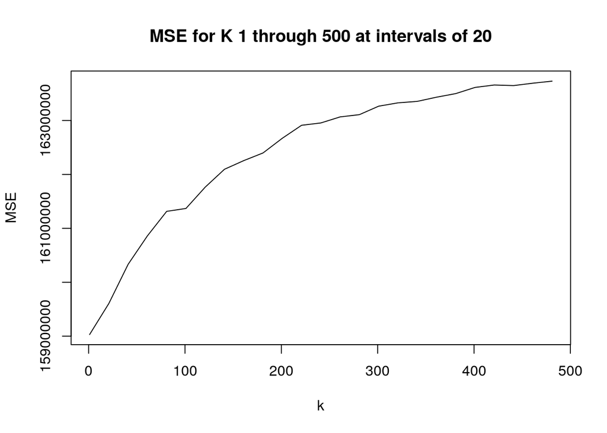

```r
#read in all the stored k values
knn_mse_k1_k500_by20 <- read_csv(here("model_results", "knn", "knn_mse_k1_k500_by20.csv"))

knn_mse_k1_k20_by1 <- read_csv(here("model_results", "knn", "knn_mse_k1_k20_by1.csv"))

#plot MSE for values of k
plot(knn_mse_k1_k500_by20$allK, knn_mse_k1_k500_by20$k_mse, type = "l", xlab = "k", ylab = "MSE", main = "MSE for K 1 through 500 at intervals of 20")
```

When we look at K 1-20 we get the lowest MSE at around 3 before it starts increasing.

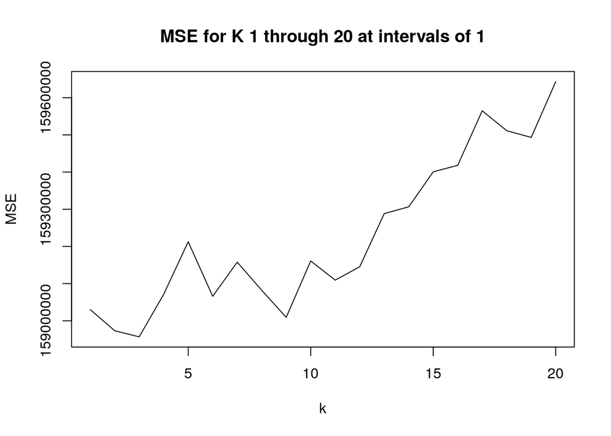

```r
plot(knn_mse_k1_k20_by1$allK, knn_mse_k1_k20_by1$k_mse, type = "l", xlab = "k", ylab = "MSE", main = "MSE for K 1 through 20 at intervals of 1")
```

Just to confirm, we will print out the best number of neighbors.

```r
#best number of neighbors
numneighbor = max(knn_mse_k1_k20_by1$allK[knn_mse_k1_k20_by1$k_mse == min(knn_mse_k1_k20_by1$k_mse)])

#print best number of neighbors
numneighbor
```

```
## [1] 3
```

Now that we’ve found the best number of nearest neighbors to consider, we try out KNN on our test data! Below is the test MSE and the test RMSE.

```r
#fit KNN model with best neighbor value to test data
pred.YTest = knn(train = XTrain, test = XTest, cl = YTrain, k = numneighbor)

#predict KNN
test_MSE <- mean((as.numeric(pred.YTest) - YTest)^2)

#print test MSE
test_MSE
```

```
## [1] 83563638
```

```r
#print test RMSE
sqrt(test_MSE)
```

```
## [1] 9141.315
```

Over all, this model performs okay.

### 2.4.3 Boosted Tree

Gradient boosted decision trees partition data by asking questions about that data (create single trees) and combines individual trees by using the boosting method. The boosting method basically seeks to achive a strong learner from many sequentially connected weak learners combining a learning algorithm in series, where the weak learners in this method are single decision trees. This method iteratively adds a tree, and everytime a tree is added, it fits the new version that contains one more tree, but focusing on minimizing the errors from the previous tree. The sequential addition of trees makes the boosting method to learn slowly, but one advantage is that models that learn slowly can perform better in terms of prediction. Gradient boosted decision trees can be used for regression purposes and also classification tasks. In this case, we perform a regression to detect the size of a fire. Since we perform a regression, the MSE is used to detect the residuals and therefore it helps us determine whether it performs well or not comparing to the other methods. We again use the training data to train the model and the test data to test how can it perform under new observations.

```r
#train boosted tree model
set.seed(123)
fire_train <- as.data.frame(unclass(fire_train),         # Convert all columns to factor
                            stringsAsFactors = T)
fire_test <- as.data.frame(unclass(fire_test),
                           stringsAsFactors = T)
fire_size_boost = gbm(fire_size~.,
                      data = fire_train,
                      n.trees = 1000,
                      shrinkage = 0.01,
                      interaction.depth = 4
                    )
```

```
## Distribution not specified, assuming gaussian ...
```

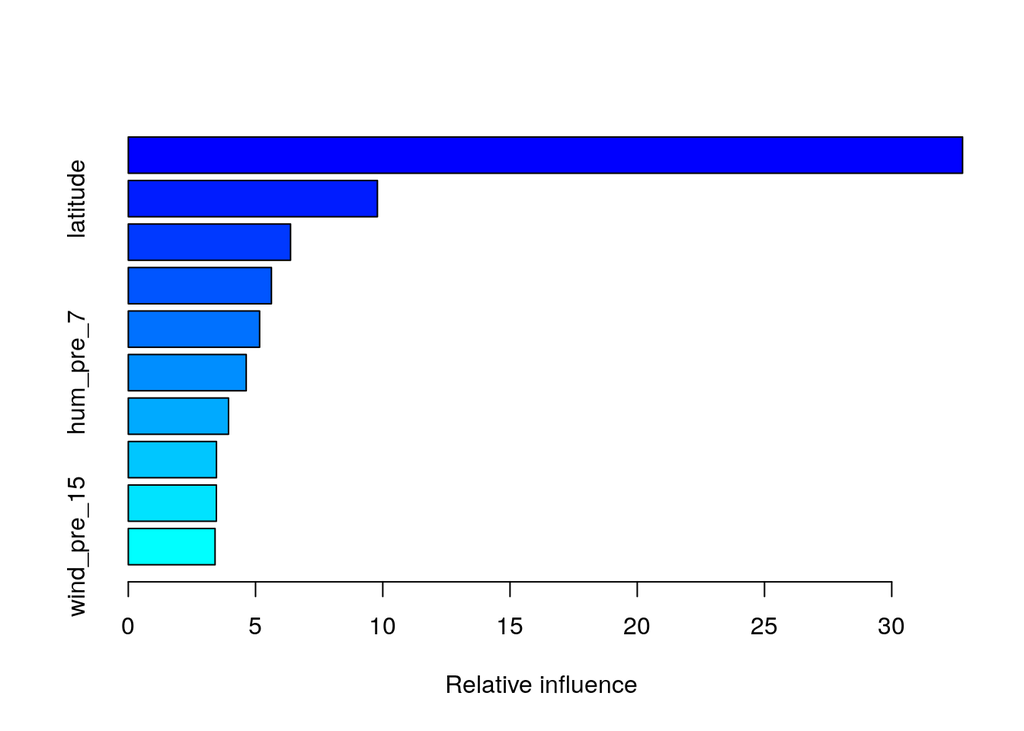

```
##                                   var     rel.inf
## fire_mag                     fire_mag 32.78320701
## latitude                     latitude  9.78938801
## wind_pre_7                 wind_pre_7  6.37503311
## hum_cont                     hum_cont  5.62419982
## temp_cont                   temp_cont  5.16031427
## hum_pre_7                   hum_pre_7  4.63417600
## longitude                   longitude  3.93845107
## temp_pre_30               temp_pre_30  3.46435021
## wind_pre_30               wind_pre_30  3.46126716
## wind_pre_15               wind_pre_15  3.40982314
## wind_cont                   wind_cont  3.33506116
## remoteness                 remoteness  3.17169536
## hum_pre_30                 hum_pre_30  2.79849749
## temp_pre_7                 temp_pre_7  2.59453227
## temp_pre_15               temp_pre_15  2.54279972
## year_diff                   year_diff  1.95866890
## hum_pre_15                 hum_pre_15  1.74942182
## prec_pre_15               prec_pre_15  0.93581863
## prec_pre_30               prec_pre_30  0.63358845
## vegetation_classed vegetation_classed  0.58511836
## prec_pre_7                 prec_pre_7  0.44270719
## prec_cont                   prec_cont  0.30556461
## stat_cause_descr     stat_cause_descr  0.21424633
## season                         season  0.05251140
## region                         region  0.03955851
```

```r
#the model summary creates a pretty visualization
summary(fire_size_boost,  cBars = 10,normalize = T)
```

The following plots show the relation betweeen the variables that have higher relative influence (x axis) and the mapping function $f(x)$ (in the y axis). There is a positive relation between fire magnitude and wind at location 7 days prior to wildfire with the response fire size. However, for the other variable, the relationship is not that clear.

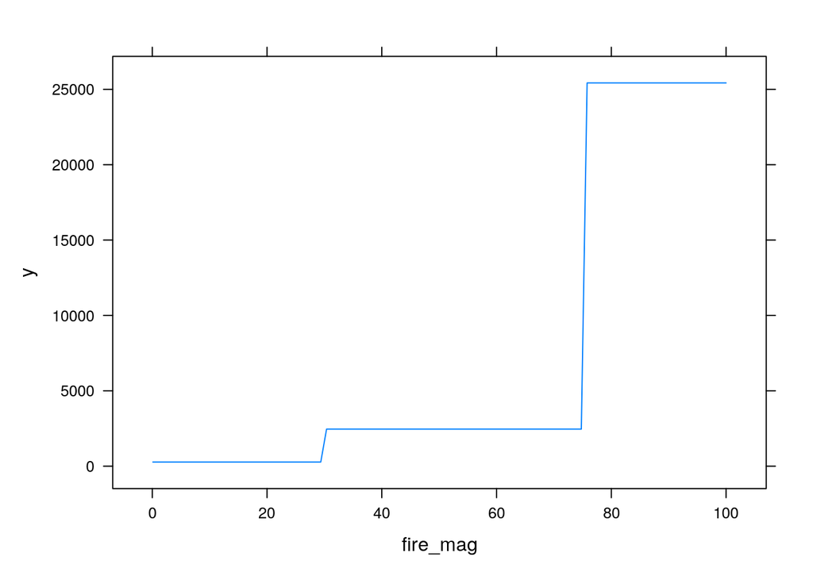

```r
plot(fire_size_boost,i="fire_mag")
```

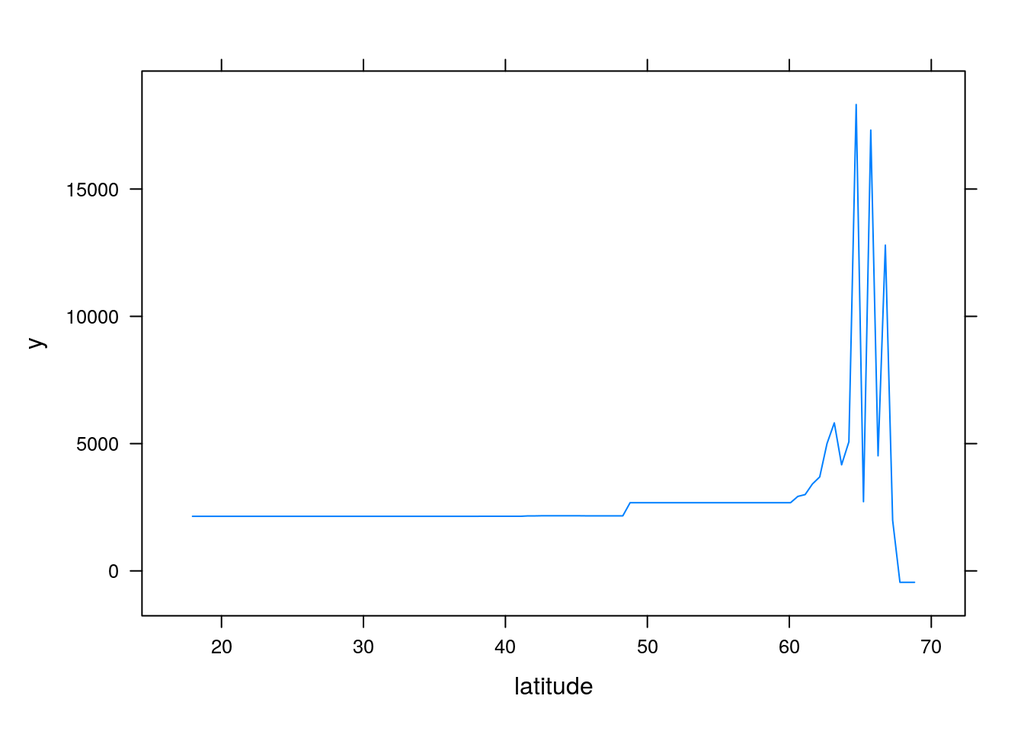

```r
plot(fire_size_boost,i="latitude")
```

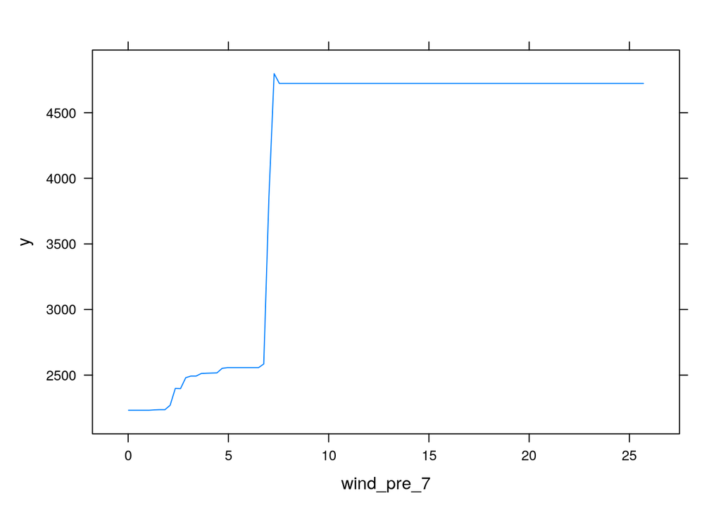

```r
plot(fire_size_boost,i="wind_pre_7")
```

Now, let us check the MSE for both, training and test datasets, respectively.

```r
#calculate training error

#predict values using training data
predictions_train_boost <- predict(fire_size_boost, data = fire_train)

#calculate rmse for training data
RMSE(predictions_train_boost, fire_train$fire_size)
```

```
## [1] 11895.52
```

```r
#calculate test error

#predict values using test data
predictions_test_boost <- predict(fire_size_boost, data = fire_test)

#calculate rmse for training data
RMSE(predictions_test_boost, fire_test$fire_size)
```

```
## [1] 14516.33
```

Next, we calculate the error as a function of number of trees from 100 to 1000 with a step of 10 and create a prediction matrix that contains in its columns the predictions for each tree size.

```r
###compute test error as a function of number of trees
n.trees = seq(from=100 ,to=1000, by=10) #vector containing different number of trees
```

The dimension of the prediction matrix is

```r
#create a prediction matrix for each tree
predmatrix<-predict(fire_size_boost, data = fire_test,n.trees = n.trees)
dim(predmatrix) #dimentions of the Prediction Matrix
```

```
## [1] 32903    91
```

This is a sample of the test error calculated for each of the 100 trees averaged.

```r
#calculate the MSE
test.error<-with(fire_test,apply( (predmatrix-fire_size)^2,2,mean))
head(test.error) #contains the Mean squared test error for each of the 100 trees averaged
```

```
##       100       110       120       130       140       150
## 164497747 167577345 173184416 174104158 176827307 178637091
```

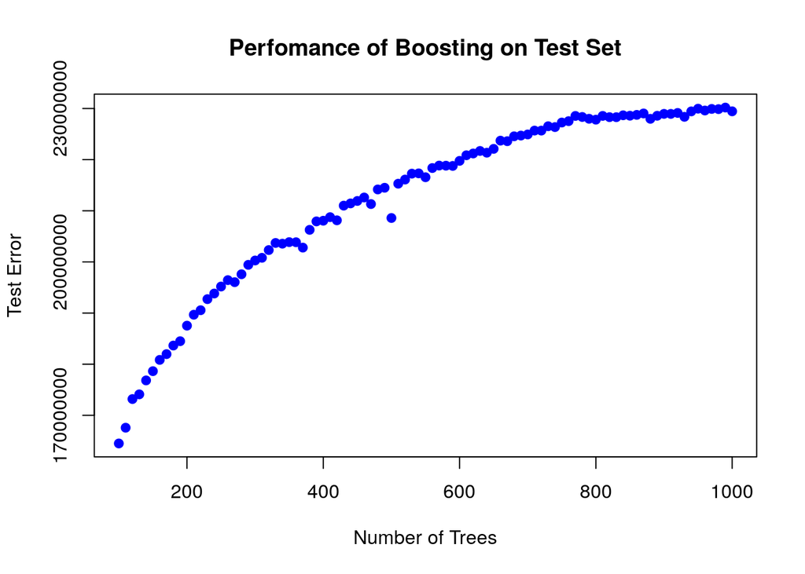

```r
#Plotting the test error vs number of trees

plot(n.trees , test.error , pch=19,col="blue",xlab="Number of Trees",ylab="Test Error", main = "Perfomance of Boosting on Test Set")
```

### 2.4.4 Random Forest

Random forest is also a supervised method to perform regression and clasification tasks. It also creates single trees at random using a boostraping sampling method, also called *bagging*. It trains each tree independently and combine them by computing the average of all trees estimators. Since every tree is separately trained, it is difficult for this method to suffer overfiting when increasing the tree size, however, larger tree sizes makes this model computationally slow. We perform a random forest model for the same data used for boosted trees.

```r
#train model
set.seed(123)
fire_size_rf = randomForest(fire_size ~ ., #writing the formula
                          data = fire_train, #specifying training data to be used
                          mtry = 9, #setting number of variables to randomly sample per each split
                          ntree= 500, #setting number of trees
                          mode = "regression", #specifying regression
                          na.action = na.omit, #specifying what to do with NAs
                          importance = TRUE #specifying importance of variables should be assessed
                          )
```

9 variables were considered at each split and 500 trees were used to fit the data.

```r
print(fire_size_rf)
```

```
##
## Call:
##  randomForest(formula = fire_size ~ ., data = fire_train, mtry = 9,      ntree = 500, mode = "regression", importance = TRUE, na.action = na.omit)
##                Type of random forest: regression
##                      Number of trees: 500
## No. of variables tried at each split: 9
##
##           Mean of squared residuals: 154004359
##                     % Var explained: 25.23
```

The error decreases as the tree size increases.

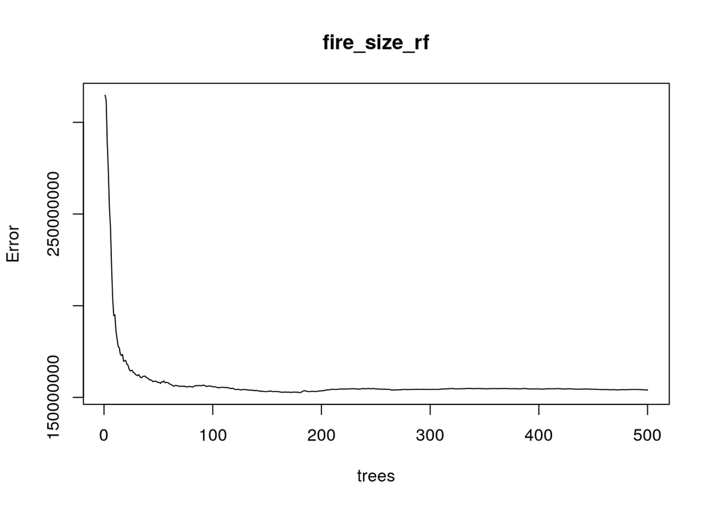

```r
#plot error
plot(fire_size_rf)
```

We also check the variable importance for fire size, where the variables that explain better fire size are fire magnitude, remoteness, wind at the location up to the day the fire was contained, precipitation at the location up to the day the fire was contained and temperature at the location up to the day the fire was contained. There is a consensus between boosted trees model and random forest model in 2 of the variables that are important for explaining fire size: fire magnitude, and temperature at the location up to the day the fire was contained.

```r
#check the importance
fire_size_rf$importance
```

```
##                        %IncMSE IncNodePurity
## stat_cause_descr     1618194.4   65936239167
## latitude            77823097.9  135399915982
## longitude           91667680.7  160342107188
## fire_mag           125010760.4  558763700428
## temp_pre_30         33338958.3   78422695200
## temp_pre_15         27024401.1   62211908093
## temp_pre_7          24448882.9   78765473770
## temp_cont           42830677.9  101112769893
## wind_pre_30         28763676.2   95867580745
## wind_pre_15         43424342.4  113537794443
## wind_pre_7          22303829.6  112525652590
## wind_cont           23127806.5  100915813569
## hum_pre_30          99512937.4  123219123842
## hum_pre_15          91862141.6  139442136182
## hum_pre_7           37196513.9  143524824038
## hum_cont            45704901.6  220705725708
## prec_pre_30          7315076.7   32459610447
## prec_pre_15          9486495.6   27212384055
## prec_pre_7          44291391.6   51870149158
## prec_cont           25981428.6   54127563905
## remoteness          31685070.6  216939173819
## region              32523285.6   17120832986
## year_diff             112776.6   48112327317
## vegetation_classed  38415055.7   44639852545
## season               1410184.1    9142551802
```

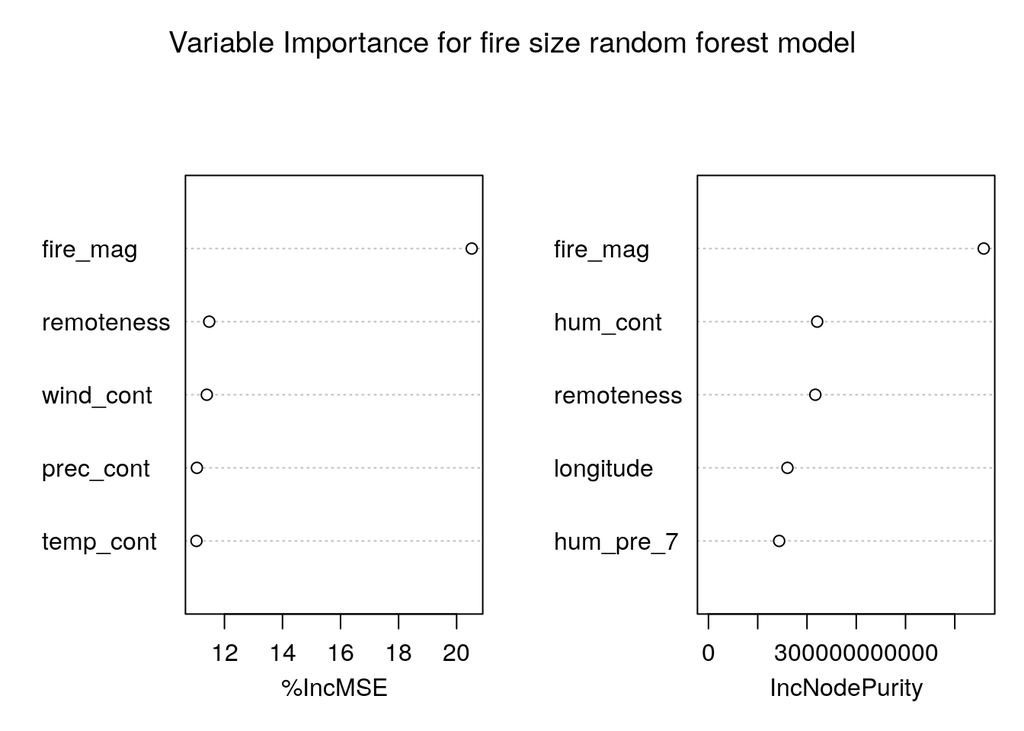

```r
#plot variable importance
varImpPlot(fire_size_rf,
           sort = T,
           main = "Variable Importance for fire size random forest model",
           n.var = 5)
```

Next, we compute the RMSE on the train and test datasets, respectively. The RMSE for this model is higher for the training dataset than in the case of the boosted trees model, but it is better on the testing dataset, which means, surprisingly, that the prediction power of the random forest model performs better than the boosted trees model.

```r
#calculate training error

#predict values using training data
predictions_train_rf <- predict(fire_size_rf, data = fire_train)

#calculate rmse for training data
RMSE(predictions_train_rf, fire_train$fire_size)
```

```
## [1] 17832.55
```

```r
#calculate test error

#predict values using test data
predictions_test_rf <- predict(fire_size_rf, data = fire_test)

#calculate rmse for test data
RMSE(predictions_test_rf, fire_test$fire_size)
```

```
## [1] 12933.74
```

```r
#Plotting the test error vs number of trees
```

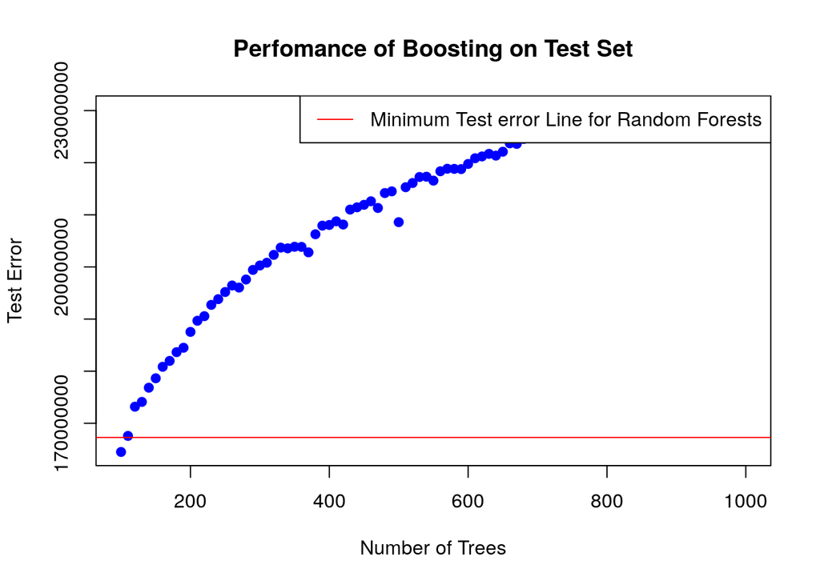

```r
plot(n.trees , test.error , pch=19,col="blue",xlab="Number of Trees",ylab="Test Error", main = "Perfomance of Boosting on Test Set")

#adding the RandomForests Minimum Error line trained on same data and similar parameters
abline(h = (RMSE(predictions_test_rf, fire_test$fire_size))^2,col="red") # test error of a Random forest fitted on same data
legend("topright",c("Minimum Test error Line for Random Forests"),col="red",lty=1,lwd=1)
```

# 3 Results

# 4 Conclusion

Wildfires have intensified in the last couple decades in United States. Since wildifres can affect in multiple ways, not only damaging structures and generating important losses, but affecting vulnerable population, especially when the size of fires scalate out of proportions. Therefore, predicting the size of a fires can serve as support to prevent catastrophes. With that purpose, we tried different methods to predict the size of a fire in case a wildfire occurs including linear regression with dimensionality reduction through PCA, K-NN regression, random forest regression, and boosted trees. We find that the RMSE on the test data is lower for K-NN regression, which means that K-NN is the method with the best predictive power. Regarding random forest and boosted trees, random forest performed better. Boosted trees is sensitive to outliers and requires a carefully tunning of hyperparameters, meanwhile random forest is not affected by the number of trees, then it tends to not suffer from overfiting.

Keeley, J. E., Safford, H., Fotheringham, C., Franklin, J., & Moritz, M. (2009). The 2007 southern california wildfires: Lessons in complexity. *Journal of Forestry*, *107*(6), 287–296.

Stephens, S. L., Martin, R. E., & Clinton, N. E. (2007). Prehistoric fire area and emissions from california’s forests, woodlands, shrublands, and grasslands. *Forest Ecology and Management*, *251*(3), 205–216.